# Modelo Lineal Multivariado - Clase 4

Cecilia Oliva

21/06/2023

# Modelo lineal mulivariado

## Métodos de regularización

### Ejemplo de pesos de recién nacidos

Analizamos los siguientes datos que corresponden a mediciones de 100 niños nacidos con bajo peso (es decir, con menos de 1500 g.) en Boston, Massachusetts.

Las variables que usaremos son:

headcirc: es el perímetro cefálico (medido en cm.) de un bebé recién nacido con bajo peso,

gestage: es la edad gestacional o duración de la gestación del i-ésimo bebé de bajo peso,

birthwt: es el peso al nacer del i-ésimo niño, en gramos.

```r
file<-"low birth weight infants.txt"

data <- read.table(file = file, header = TRUE)
head(data)
```

|  | headcirc | length | gestage | birthwt | momage | toxemia |
| --- | --- | --- | --- | --- | --- | --- |
| 1 | 27 | 41 | 29 | 1360 | 37 | 0 |
| 2 | 29 | 40 | 31 | 1490 | 34 | 0 |
| 3 | 30 | 38 | 33 | 1490 | 32 | 0 |
| 4 | 28 | 38 | 31 | 1180 | 37 | 0 |
| 5 | 29 | 38 | 30 | 1200 | 29 | 1 |
| 6 | 23 | 32 | 25 | 680 | 19 | 0 |

## Ridge

La función glmnet() estandariza por defecto las variables antes de realizar el ajuste del modelo.

```r
x <- model.matrix(headcirc ~ ., data = data)[, -1]
head(x)
```

```
##   length gestage birthwt momage toxemia
## 1     41      29    1360     37       0
## 2     40      31    1490     34       0
## 3     38      33    1490     32       0
## 4     38      31    1180     37       0
## 5     38      30    1200     29       1
## 6     32      25     680     19       0
```

```r
y <- data$headcirc
```

Para obtener un ajuste mediante regresión Ridge se indica argumento alpha=0.

```r
#install.packages("glmnet")
library(glmnet)
```

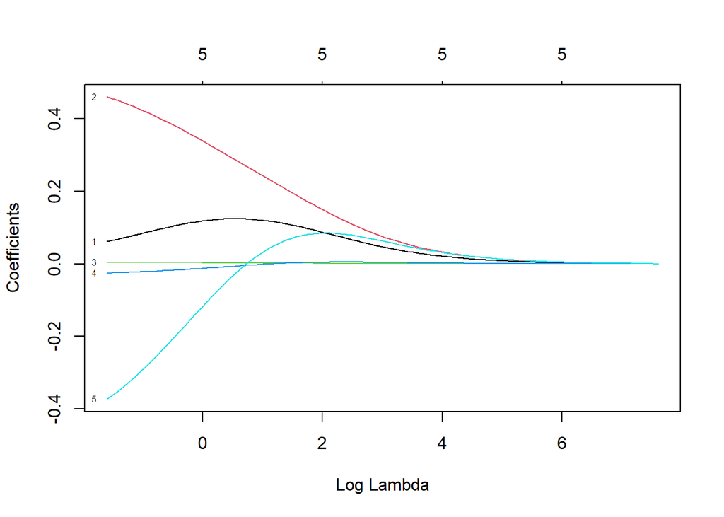

```r
modelos_ridge <- glmnet(x = x, y = y, alpha = 0)

plot(modelos_ridge, xvar = "lambda", label = TRUE)
```

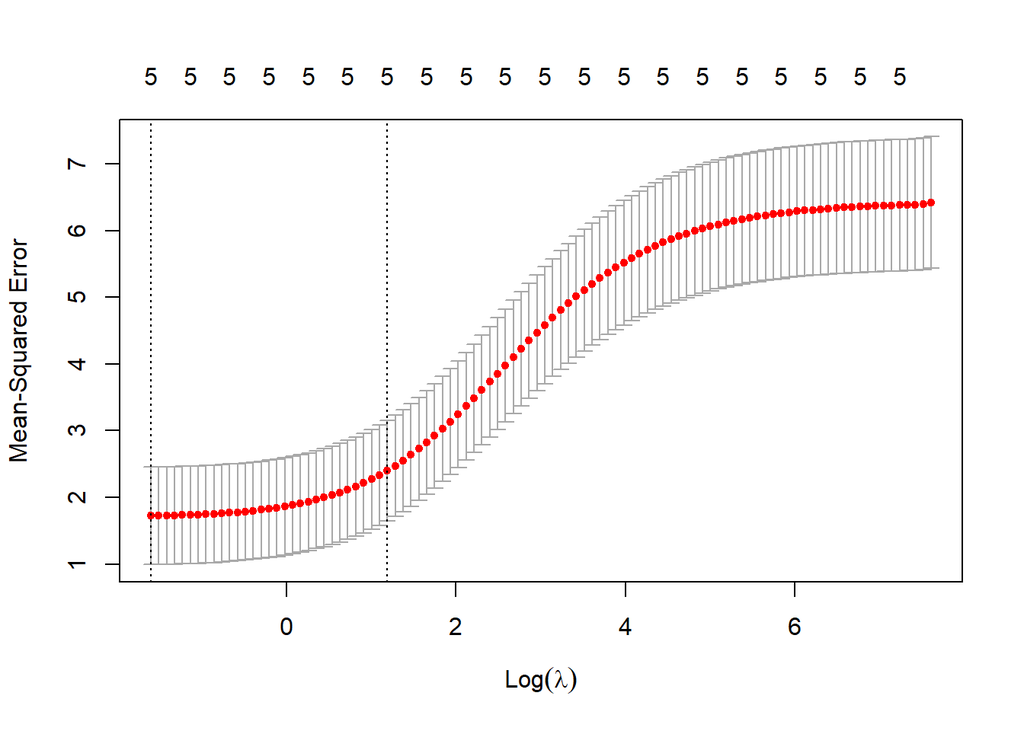

```r
set.seed(1)
# x e y son la matriz modelo y el vector respuesta creados anteriormente con
# los datos
cv_error_ridge <- cv.glmnet(x = x, y = y, alpha = 0, nfolds = 10, type.measure = "mse")
plot(cv_error_ridge)
```

Valor lambda con el que se consigue el mínimo test-error:

```r
cv_error_ridge$lambda.min
```

```
## [1] 0.201261
```

Valor lambda óptimo: mayor valor de lambda con el que el test-error no se aleja más de 1 sd del mínimo test-error posible.

```r
cv_error_ridge$lambda.1se
```

```
## [1] 3.280053
```

Se muestra el valor de los coeficientes para el valor de lambda óptimo.

```r
modelo_final_ridge <- glmnet(x = x, y = y, alpha = 0, lambda = 3.280053)
coef(modelo_final_ridge)
```

```
## 6 x 1 sparse Matrix of class "dgCMatrix"
##                       s0
## (Intercept) 1.334702e+01
## length      1.159928e-01
## gestage     2.251367e-01
## birthwt     2.104546e-03
## momage      1.731945e-04
## toxemia     5.021144e-02
```

## Lasso

Para obtener un ajuste mediante regresión Lasso se indica argumento alpha=1.

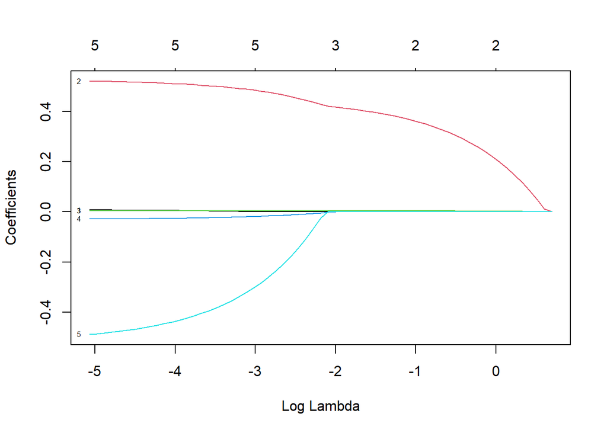

```r
modelos_lasso <- glmnet(x = x, y = y, alpha = 1)
plot(modelos_lasso, xvar = "lambda", label = TRUE)
```

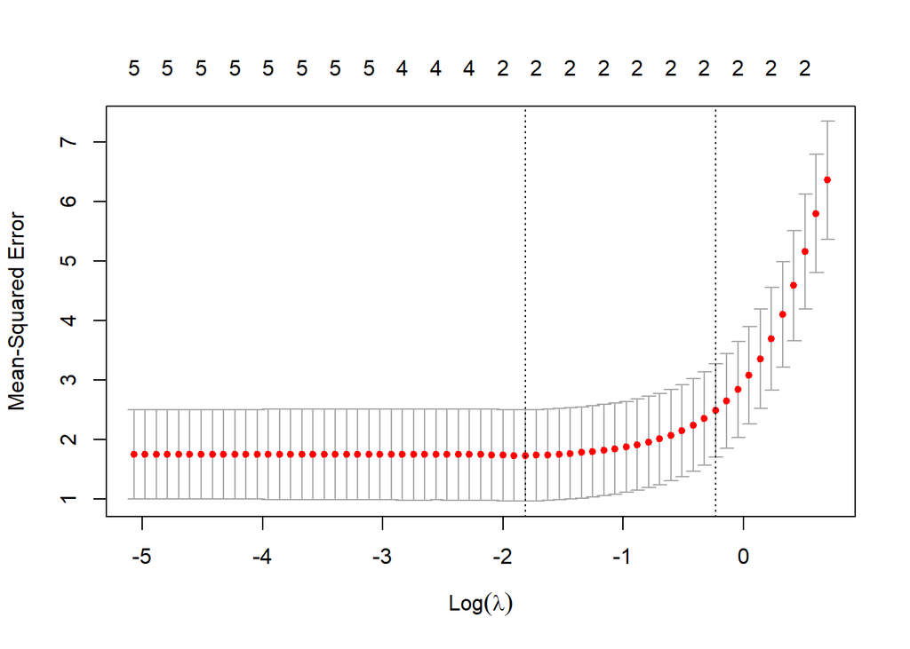

```r
set.seed(1)
cv_error_lasso <- cv.glmnet(x = x, y = y, alpha = 1, nfolds = 10)
plot(cv_error_lasso)
```

```r
cv_error_lasso$lambda.min
```

```
## [1] 0.163249
```

```r
cv_error_lasso$lambda.1se
```

```
## [1] 0.7938149
```

Se reajusta el modelo con todas las observaciones empleando el valor de lambda óptimo.

```r
modelo_final_lasso <- glmnet(x=x, y=y, alpha=1,lambda=cv_error_lasso$lambda.1se)
coef(modelo_final_lasso)
```

```
## 6 x 1 sparse Matrix of class "dgCMatrix"
##                      s0
## (Intercept) 15.74191392
## length       .
## gestage      0.25913999
## birthwt      0.00293173
## momage       .
## toxemia      .
```

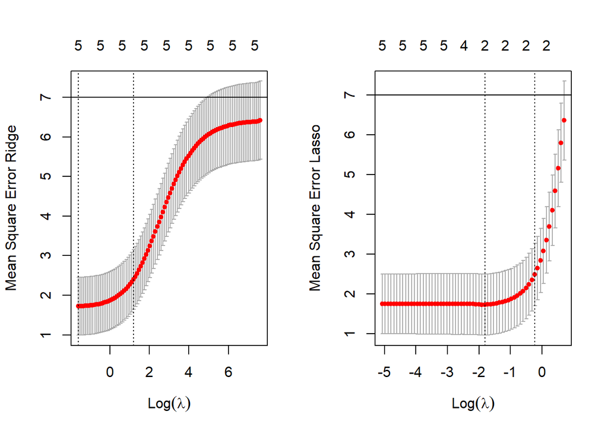

```r
par(mfrow = c(1, 2))
plot(cv_error_ridge, ylab = "Mean Square Error Ridge")
abline(h = 7)
plot(cv_error_lasso, ylab = "Mean Square Error Lasso")
abline(h = 7)
```

```r
par(mfrow = c(1, 1))
```

# Modelos basados en PCA

## Regresión basada en componentes principales

### Ejemplo de datos de niños de bajo peso al nacer

Analizamos los siguientes datos que corresponden a mediciones de 100 niños nacidos con bajo peso (es decir, con menos de 1500g.) en Boston, Massachusetts.

Las variables que usaremos son:

headcirc: es el perímetro cefálico (medido en cm.) de un bebé recién nacido con bajo peso,

gestage: es la edad gestacional o duración de la gestación del bebé de bajo peso,

birthwt: es el peso al nacer del niño, en gramos,

length: es la altura aproximada del bebé,

momage: es la edad de la mamá del bebé,

toxemia: es 1 si el bebé tiene presencia de sustancias tóxicas en la sangre y 0 sino.

```r
file<-"low birth weight infants.txt"

data <- read.table(file = file, header = TRUE)
head(data)
```

|  | headcirc | length | gestage | birthwt | momage | toxemia |
| --- | --- | --- | --- | --- | --- | --- |
| 1 | 27 | 41 | 29 | 1360 | 37 | 0 |
| 2 | 29 | 40 | 31 | 1490 | 34 | 0 |
| 3 | 30 | 38 | 33 | 1490 | 32 | 0 |
| 4 | 28 | 38 | 31 | 1180 | 37 | 0 |
| 5 | 29 | 38 | 30 | 1200 | 29 | 1 |
| 6 | 23 | 32 | 25 | 680 | 19 | 0 |

```r
dim(data)
```

```
## [1] 100   6
```

```r
data <- na.omit(data)
data<- data[,-6]#quitamos la variable categórica
```

### PCR

Es importante estandarizar las variables indicándolo con el argumento scale=TRUE. Indicando validation = CV, se emplea 10-fold-cross-validation para identificar el número óptimo de componentes.

```r
library(pls)
set.seed(2)
modelo_pcr <- pcr(headcirc ~ ., data = data, scale = TRUE, validation = "CV")
summary(modelo_pcr)
```

```
## Data:    X dimension: 100 4
##  Y dimension: 100 1
## Fit method: svdpc
## Number of components considered: 4
##
## VALIDATION: RMSEP
## Cross-validated using 10 random segments.
##        (Intercept)  1 comps  2 comps  3 comps  4 comps
## CV           2.545    1.437    1.372    1.351    1.309
## adjCV        2.545    1.435    1.370    1.348    1.306
##
## TRAINING: % variance explained
##           1 comps  2 comps  3 comps  4 comps
## X           63.11    86.23    95.46   100.00
## headcirc    68.63    71.97    73.59    75.66
```

El summary devuelve la estimación del RMSEP (raíz cuadrada del MSE) para cada posible número de componentes introducidas en el modelo. También se muestra el % de varianza explicada acumulada por cada número de componentes.

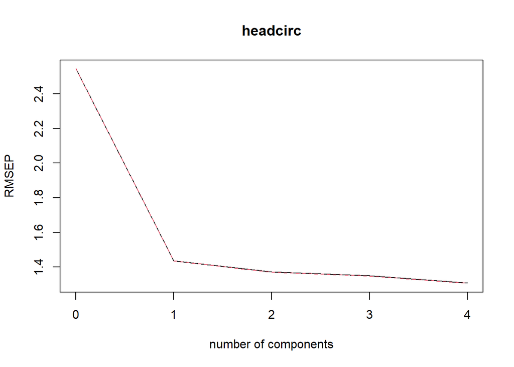

```r
validationplot(modelo_pcr, val.type = "RMSEP")
```

Para conocer el número de componentes con el que se minimiza el error:

```r
which.min(x = modelo_pcr$validation$PRESS)
```

```
## [1] 4
```

Si bien el menor error se alcanza con 4 componentes, se observa que a partir de la primera componente la mejora es mínima. El modelo que incluye únicamente la primera componente cumple el principio de parsimonia.

### PLS

```r
set.seed(123)
modelo_pls <- plsr(formula = headcirc ~ ., data = data, scale. = TRUE, validation = "CV")
summary(modelo_pls)
```

```
## Data:    X dimension: 100 4
##  Y dimension: 100 1
## Fit method: kernelpls
## Number of components considered: 4
##
## VALIDATION: RMSEP
## Cross-validated using 10 random segments.
##        (Intercept)  1 comps  2 comps  3 comps  4 comps
## CV           2.545    1.541    1.415    1.323    1.299
## adjCV        2.545    1.540    1.402    1.320    1.296
##
## TRAINING: % variance explained
##           1 comps  2 comps  3 comps  4 comps
## X           99.94    99.96   100.00   100.00
## headcirc    63.82    72.95    74.86    75.66
```

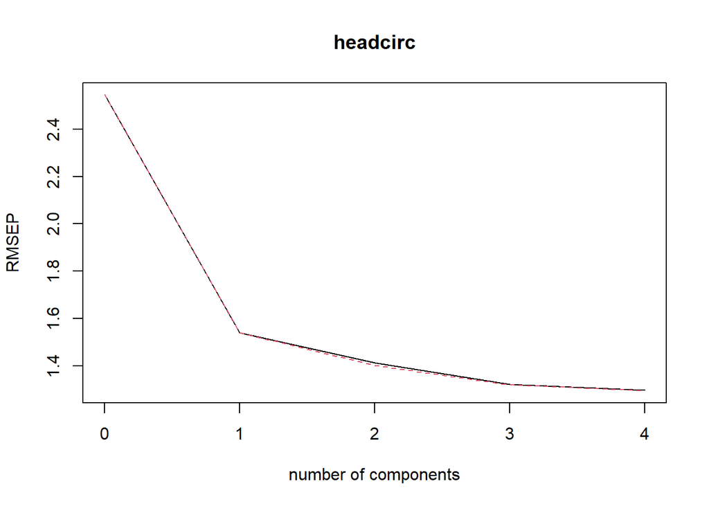

```r
validationplot(modelo_pls, val.type = "RMSEP")
```

```r
which.min(x = modelo_pls$validation$PRESS)
```

```
## [1] 4
```

Nuevamente, aunque el menor error se alcanza con 4 componentes, se observa que a partir de la primera componente la mejora es mínima. El modelo que incluye únicamente la primera componente cumple el principio de parsimonia.

## Comparación de modelos

### Regresión por mínimos cuadrados

```r
set.seed(1)
indices_entrenamiento <- sample(x = 1:nrow(data), size = round(nrow(data) * (2/3)))
# 2/3 de las observaciones
indices_test <- (1:nrow(data))[-indices_entrenamiento]
data_1 <- data[indices_entrenamiento, ]
data_2 <- data[indices_test, ]

#Ordinary least square (regresión por mínimos cuadrados)
modelo_OLS <- lm(formula = headcirc ~ ., data = data_1)
test_MSE_OLS <- mean((predict(modelo_OLS, data_2) - data_2$headcirc)^2)
test_MSE_OLS
```

```
## [1] 3.126792
```

### Modelo con selección de variables Backward con 10-cross validation

```r
require(leaps)
```

```r
require(ggplot2)
set.seed(2)
grupo <- sample(rep(x = 1:10, length = nrow(data_1)))

predict.regsubsets <- function(object, newdata, id, ...) {
  # Extraer la fórmula del modelo (variable dependiente ~ predictores)
  form <- as.formula(object$call[[2]])
  # Generar una matriz modelo con los nuevos datos y la fórmula
  mat <- model.matrix(form, newdata)
  # Extraer los coeficientes del modelo
  coefi <- coef(object, id = id)
  # Almacenar el nombre de las variables predictoras del modelo
  xvars <- names(coefi)
  # Producto matricial entre los coeficientes del modelo y los valores de los
  # predictores de las nuevas observaciones para obtener las predicciones
  mat[, xvars] %*% coefi }
# Matriz que almacena los test-error estimados. Cada columna representa un
# modelo Cada fila es uno de los 10 grupos en los que se han dividido las
# observaciones
error_matrix <- matrix(data = NA, nrow = 10, ncol = 4, dimnames = list(NULL, c(1:4)))
# Loop en el que se excluye en cada iteración un grupo distinto
for (k in 1:10) {
  # Identificación de data empleados como training
  train <- data_1[grupo != k, ]
  # Selección de los mejores modelos para cada tamaño basándose en RSS
  mejores_modelos <- regsubsets(headcirc ~ ., data = train, nvmax = 4, method = "backward")
  # Para cada uno de los modelos 'finalistas' se calcula el test-error con el
  # grupo excluido
  for (i in 1:4) {
    test <- data_1[grupo == k, ]
    # Las predicciones del modelo i almacenado en el objeto regsubsets se
    # extraen mediante la función predict.regsubsets() definida arriba
    predicciones <- predict.regsubsets(object = mejores_modelos, newdata = test, id = i)
    # Cálculo y almacenamiento del MSE para el modelo i
    error_matrix[k, i] <- mean((test$headcirc - predicciones)^2) }
  }
mean_cv_error <- apply(X = error_matrix, MARGIN = 2, FUN = mean)
which.min(x = mean_cv_error)
```

```
## 2
## 2
```

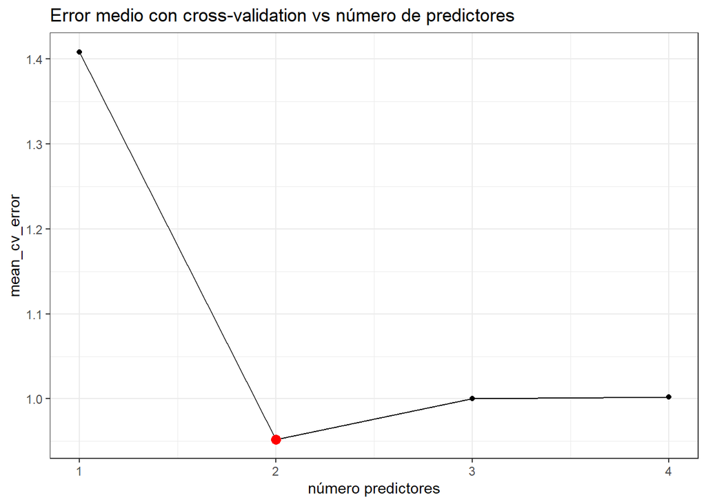

```r
ggplot(data = data.frame(n_predictores = 1:4, mean_cv_error = mean_cv_error), aes(x = n_predictores, y = mean_cv_error)) +
  geom_line() + geom_point() +
  geom_point(aes(x = n_predictores[which.min(mean_cv_error)], y = mean_cv_error[which.min(mean_cv_error)]), colour = "red", size = 3) +
  scale_x_continuous(breaks = c(0:4)) + theme_bw() +
  labs(title = "Error medio con cross-validation vs número de predictores", x = "número predictores")
```

Generamos el modelo final sabiendo la cantidad de predictores óptima usando Backward.

```r
modelo_final <- regsubsets(headcirc ~ ., data = data_1, nvmax = 4, method = "backward")
coef(object = modelo_final, 2)
```

```
## (Intercept)     gestage     birthwt
## 9.881296494 0.353360252 0.005747135
```

Como el modelo está dentro de un objeto regsubsets, en predict() se tiene que identificar el id.

```r
test_MSE_Back <- mean((predict(modelo_final, data_2, id = 2)-data_2$headcirc)^2)
test_MSE_Back
```

```
## [1] 3.145154
```

### Regresión Ridge

La función glmnet() requiere pasar los predictores como matriz y la variable dependiente como vector.

```r
x_data_1 <- model.matrix(headcirc ~ ., data = data_1)[, -1]
y_data_1 <- data_1$headcirc
x_data_2 <- model.matrix(headcirc ~ ., data = data_2)[, -1]
y_data_2 <- data_2$headcirc
```

Se identifica mediante k-cross-validation el mejor valor de lambda para la regresión de Ridge.

```r
library(glmnet)
set.seed(1)
cv_error_ridge <- cv.glmnet(x=x_data_1, y = y_data_1, alpha = 0, nfolds = 10, type.measure = "mse")
# Para obtener un ajuste mediante *ridge regression* se indica argumento alpha=0
modelo_ridge <- glmnet(x = x_data_1, y = y_data_1, alpha = 0, lambda = cv_error_ridge$lambda.1se)
# Se almacenan las predicciones en una variable separada para no concatenar
# tanto código
predicciones <- predict(object = modelo_ridge, newx = x_data_2, s = cv_error_ridge$lambda.1se, exact = TRUE)
test_MSE_ridge <- mean((predicciones - data_2$headcirc)^2)
test_MSE_ridge
```

```
## [1] 3.286477
```

### LASSO

```r
library(glmnet)
set.seed(1)
# Se identifica mediante k-cross-validation el mejor valor de lambda para lasso
cv_error_lasso <- cv.glmnet(x = x_data_1, y = y_data_1, alpha = 1, nfolds = 10, type.measure = "mse")
# Para obtener un ajuste mediante lasso se indica argumento alpha=1
modelo_lasso <- glmnet(x = x_data_1, y = y_data_1, alpha = 1, lambda = cv_error_lasso$lambda.1se)
# Se almacenan las predicciones en una variable separada
predicciones <- predict(object = modelo_lasso, newx = x_data_2, s = cv_error_lasso$lambda.1se, exact = TRUE)
test_MSE_lasso <- mean((predicciones - data_2$headcirc)^2)
test_MSE_lasso
```

```
## [1] 3.238432
```

### PCR

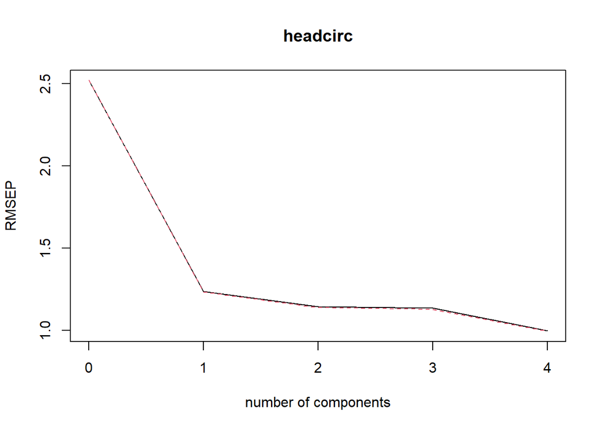

```r
library(pls)
set.seed(123)
modelo_pcr <- pcr(headcirc ~ ., data = data_1, scale = TRUE, validation = "CV")
validationplot(modelo_pcr, val.type = "RMSEP")
```

Para evaluar el modelo consideramos la primera componente, dado que agregar más no mejora significativamente.

```r
set.seed(123)
which.min(x = modelo_pcr$validation$PRESS)#Para conocer el número de componentes con el que se minimiza el error
```

```
## [1] 4
```

```r
predicciones <- predict(object = modelo_pcr, newdata = data_2, ncomp = 1)
test_MSE_PCR <- mean((predicciones - data_2$headcirc)^2)
test_MSE_PCR
```

```
## [1] 3.679217
```

### PLS

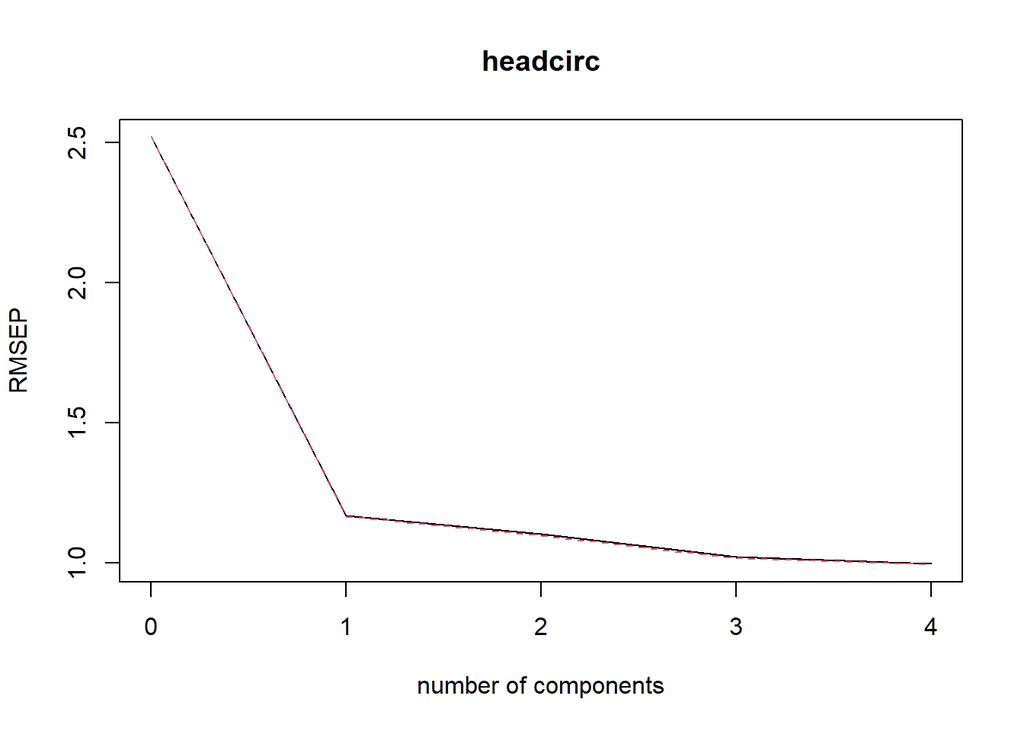

```r
set.seed(123)
modelo_pls <- plsr(headcirc ~ ., data = data_1, scale = TRUE, validation = "CV")
validationplot(modelo_pls, val.type = "RMSEP")
```

Nuevamente, para evaluar el modelo consideramos la primera componente, dado que agregar más no mejora significativamente.

```r
which.min(x = modelo_pls$validation$PRESS)#Para conocer el número de componentes con el que se minimiza el error
```

```
## [1] 4
```

```r
predicciones <- predict(object = modelo_pls, newdata = data_2, ncomp = 1)
test_MSE_PLS <- mean((predicciones - data_2$headcirc)^2)
test_MSE_PLS
```

```
## [1] 3.397008
```

### Comparación de modelos

```r
metodo <- c("OLS", "Backward", "Regresión Ridge", "LASSO", "PCR", "PLS")
test_MSE <- c(test_MSE_OLS, test_MSE_Back, test_MSE_ridge, test_MSE_lasso, test_MSE_PCR,test_MSE_PLS)
resultados <- data.frame(metodo, test_MSE)
resultados
```

| metodo | test_MSE |
| --- | --- |
| OLS | 3.126792 |
| Backward | 3.145154 |
| Regresión Ridge | 3.286477 |
| LASSO | 3.238432 |
| PCR | 3.679217 |
| PLS | 3.397008 |

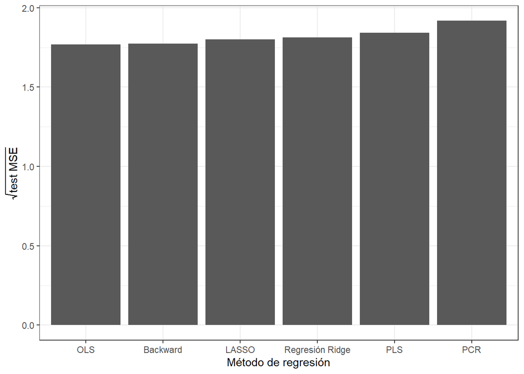

```r
ggplot(data = resultados, aes(x = reorder(metodo, test_MSE), y = sqrt(test_MSE))) +
  geom_bar(stat = "identity") +
  labs(x = "Método de regresión", y = expression(sqrt("test MSE"))) + theme_bw()
```